[View Project Website](https://kaileesegarra.github.io/dermatology-no-show-analysis/)

# Predicting Medical Appointment No-Shows with Logistic Regression

**Student:** Kailee Segarra  
**Course:** CMPS 6790 Data Science

## Data Science Lifecycle Roadmap

1. **Question and Motivation** — Why missed appointments matter and what data science can add.
2. **Data Collection** — Where the appointment data and supplemental socioeconomic context come from.
3. **Data Cleaning and Feature Engineering** — How raw appointment records are transformed into model-ready variables.
4. **Exploratory Data Analysis** — What patterns appear before modeling.
5. **Modeling and Testing** — Logistic regression model, train/test split, evaluation metrics, and feature interpretation.
6. **Conclusions and Recommendations** — What the model suggests and how healthcare teams could use the findings responsibly.

## 1. Question and Motivation

Missed medical appointments are a practical healthcare problem and a useful data science problem. In clinics, no-shows create unused appointment slots, longer wait times, delayed care, and inefficiencies for providers and staff. From a patient perspective, missing an appointment can delay diagnosis, treatment, medication refills, or follow-up care. This is especially important in outpatient specialties such as dermatology, where patients may be monitoring changing lesions, chronic inflammatory skin disease, post-procedure healing, or medication side effects.

The central question for this tutorial is:

> **Can appointment scheduling, reminder, demographic, and neighborhood-level variables help predict whether a patient will miss a medical appointment?**

This question is appropriate for data science because the outcome is measurable, binary, and operationally meaningful. Each appointment is labeled as either attended or missed, allowing this project to frame no-show prediction as a classification task. The goal is not to replace human judgment or make punitive decisions about patients. Instead, the model can help identify patterns that may support better scheduling workflows, reminder strategies, and patient outreach.

This final tutorial builds on the exploratory work from Milestones 1 and 2. Peer and instructor feedback emphasized that the project needed to move beyond EDA and clearly show model implementation, testing, and results. Therefore, the final version uses EDA to motivate the choice of predictors and then tests whether those predictors can support a logistic regression classifier.

From a data science perspective, this problem naturally fits into a supervised classification framework, where historical appointment data can be used to predict future attendance outcomes and support real-world decision-making.

## 2. Resources and Data Sources

### Primary Dataset

- **[Brazilian Medical Appointment No-Show Dataset (Kaggle)](https://www.kaggle.com/datasets/joniarroba/noshowappointments)**

This dataset contains more than 100,000 appointment records from Brazil's public healthcare system. It includes demographic variables, appointment scheduling information, neighborhood, scholarship status, health condition indicators, SMS reminder status, and a final attendance outcome.

### Helpful Conceptual Resources

- **[Scikit-learn Logistic Regression](https://scikit-learn.org/stable/modules/generated/sklearn.linear_model.LogisticRegression.html)**
- **[Scikit-learn Model Evaluation Metrics](https://scikit-learn.org/stable/modules/model_evaluation.html)**
- **[Train/Test Split](https://scikit-learn.org/stable/modules/generated/sklearn.model_selection.train_test_split.html)**
- **[Confusion Matrix](https://scikit-learn.org/stable/modules/generated/sklearn.metrics.confusion_matrix.html)**

These resources provide foundational understanding of the modeling techniques and evaluation methods used in this project.

### Supplemental Dataset Note

Milestone 2 used a small manually constructed socioeconomic dataset by neighborhood. For the final project, this is treated as **illustrative only** unless the dataset is made publicly available. To ensure full reproducibility, the final model relies on the Kaggle dataset. Future work could incorporate validated and publicly available socioeconomic data sources.

### Real-World Context

A practical overview of how machine learning is used in healthcare to predict no-shows and improve scheduling efficiency can be found here:

- **[How Machine Learning Can Predict Patient No-Shows (AAPC)](https://www.aapc.com/blog/93112-can-machine-learning-predict-patient-no-shows/)**

This article provides real-world context for how predictive models are used to identify high-risk patients and support proactive scheduling and reminder strategies.

```python
# Core data analysis libraries
import pandas as pd
import numpy as np

# Visualization
import matplotlib.pyplot as plt

# Modeling and evaluation
from sklearn.model_selection import train_test_split
from sklearn.compose import ColumnTransformer
from sklearn.preprocessing import OneHotEncoder, StandardScaler
from sklearn.pipeline import Pipeline
from sklearn.linear_model import LogisticRegression
from sklearn.metrics import (
    accuracy_score,
    precision_score,
    recall_score,
    f1_score,
    roc_auc_score,
    confusion_matrix,
    ConfusionMatrixDisplay,
    RocCurveDisplay,
    classification_report
)
```

```python
# Consistent lavender theme for all project visuals
plt.rcParams.update({
    "figure.facecolor": "white",
    "axes.facecolor": "white",
    "axes.edgecolor": "#3B0A57",
    "axes.labelcolor": "#333333",
    "axes.titlecolor": "#333333",
    "xtick.color": "#333333",
    "ytick.color": "#333333",
    "text.color": "#333333",
    "grid.color": "#E8DFF0",
    "axes.titleweight": "bold",
    "axes.titlesize": 14,
    "axes.labelsize": 11,
    "font.size": 10,
})

dark_purple = "#3B0A57"
mid_purple = "#9B6BB6"
bar_purple = "#B58BD0"
light_purple = "#E5D8F0"

purple_palette = [
    "#E6D9F2",
    "#D6BFE6",
    "#C5A3D8",
    "#B184C7",
    "#9B63B6",
    "#874FA6"
]
```

## 3. Data Collection and Loading

The dataset is loaded from a public GitHub copy of the Kaggle Medical Appointment No-Show dataset so the notebook can be rerun without manual uploads.

```python
# Option A: Colab upload
# from google.colab import files
# uploaded = files.upload()

# Load the appointment dataset
url = "https://raw.githubusercontent.com/ksatola/Medical-Appointments-No-Shows/master/noshowappointments-kagglev2-may-2016.csv"

df = pd.read_csv(url)

# Preview the raw data
df.head()
```

|  | PatientId | AppointmentID | Gender | ScheduledDay | AppointmentDay | Age | Neighbourhood | Scholarship | Hipertension | Diabetes | Alcoholism | Handcap | SMS_received | No-show |
| --- | --- | --- | --- | --- | --- | --- | --- | --- | --- | --- | --- | --- | --- | --- |
| 0 | 2.987250e+13 | 5642903 | F | 2016-04-29T18:38:08Z | 2016-04-29T00:00:00Z | 62 | JARDIM DA PENHA | 0 | 1 | 0 | 0 | 0 | 0 | No |
| 1 | 5.589978e+14 | 5642503 | M | 2016-04-29T16:08:27Z | 2016-04-29T00:00:00Z | 56 | JARDIM DA PENHA | 0 | 0 | 0 | 0 | 0 | 0 | No |
| 2 | 4.262962e+12 | 5642549 | F | 2016-04-29T16:19:04Z | 2016-04-29T00:00:00Z | 62 | MATA DA PRAIA | 0 | 0 | 0 | 0 | 0 | 0 | No |
| 3 | 8.679512e+11 | 5642828 | F | 2016-04-29T17:29:31Z | 2016-04-29T00:00:00Z | 8 | PONTAL DE CAMBURI | 0 | 0 | 0 | 0 | 0 | 0 | No |
| 4 | 8.841186e+12 | 5642494 | F | 2016-04-29T16:07:23Z | 2016-04-29T00:00:00Z | 56 | JARDIM DA PENHA | 0 | 1 | 1 | 0 | 0 | 0 | No |

```python
# Show basic dataset shape and column information
print(f"Rows: {df.shape[0]:,}")
print(f"Columns: {df.shape[1]:,}")
df.info()
```

```
Rows: 110,527
Columns: 14
<class 'pandas.core.frame.DataFrame'>
RangeIndex: 110527 entries, 0 to 110526
Data columns (total 14 columns):
 #   Column          Non-Null Count   Dtype
---  ------          --------------   -----
 0   PatientId       110527 non-null  float64
 1   AppointmentID   110527 non-null  int64
 2   Gender          110527 non-null  object
 3   ScheduledDay    110527 non-null  object
 4   AppointmentDay  110527 non-null  object
 5   Age             110527 non-null  int64
 6   Neighbourhood   110527 non-null  object
 7   Scholarship     110527 non-null  int64
 8   Hipertension    110527 non-null  int64
 9   Diabetes        110527 non-null  int64
 10  Alcoholism      110527 non-null  int64
 11  Handcap         110527 non-null  int64
 12  SMS_received    110527 non-null  int64
 13  No-show         110527 non-null  object
dtypes: float64(1), int64(8), object(5)
memory usage: 11.8+ MB
```

## 4. Data Cleaning and Feature Engineering

The raw dataset is already structured as one row per appointment, which is a tidy format for this project. However, several transformations are necessary before analysis and modeling. Column names are standardized, date columns are converted to datetime values, the target variable is converted into a binary numeric variable, and new scheduling features are created.

The most important engineered feature is `lead_time_days`, which measures the number of days between when the appointment was scheduled and when it occurred. This feature is motivated by the EDA finding that longer scheduling delays appear associated with higher no-show rates.

```python
# Standardize column names
clean_df = df.copy()
clean_df.columns = (
    clean_df.columns
    .str.strip()
    .str.lower()
    .str.replace('-', '_')
)

# Convert dates
clean_df['scheduledday'] = pd.to_datetime(clean_df['scheduledday'])
clean_df['appointmentday'] = pd.to_datetime(clean_df['appointmentday'])

# Binary target: 1 = missed appointment, 0 = attended appointment
clean_df['no_show_flag'] = (clean_df['no_show'] == 'Yes').astype(int)

# Appointment lead time in days
clean_df['lead_time_days'] = (
    clean_df['appointmentday'].dt.date.astype('datetime64[ns]') -
    clean_df['scheduledday'].dt.date.astype('datetime64[ns]')
).dt.days

# Replace impossible negative lead times with missing values
clean_df.loc[clean_df['lead_time_days'] < 0, 'lead_time_days'] = np.nan

# Calendar features
clean_df['appointment_weekday'] = clean_df['appointmentday'].dt.day_name()
clean_df['scheduled_hour'] = clean_df['scheduledday'].dt.hour

# Age cleaning: remove biologically impossible ages
clean_df.loc[(clean_df['age'] < 0) | (clean_df['age'] > 115), 'age'] = np.nan

# Age groups for EDA
clean_df['age_group'] = pd.cut(
    clean_df['age'],
    bins=[0, 18, 35, 60, 115],
    labels=['0-18', '19-35', '36-60', '60+'],
    include_lowest=True
)

# Delay groups for EDA
clean_df['delay_group'] = pd.cut(
    clean_df['lead_time_days'],
    bins=[-1, 0, 3, 7, 14, 30, clean_df['lead_time_days'].max()],
    labels=['Same day', '1-3 days', '4-7 days', '8-14 days', '15-30 days', '31+ days']
)

clean_df[['no_show', 'no_show_flag', 'age', 'lead_time_days', 'appointment_weekday', 'sms_received']].head()
```

|  | no_show | no_show_flag | age | lead_time_days | appointment_weekday | sms_received |
| --- | --- | --- | --- | --- | --- | --- |
| 0 | No | 0 | 62.0 | 0.0 | Friday | 0 |
| 1 | No | 0 | 56.0 | 0.0 | Friday | 0 |
| 2 | No | 0 | 62.0 | 0.0 | Friday | 0 |
| 3 | No | 0 | 8.0 | 0.0 | Friday | 0 |
| 4 | No | 0 | 56.0 | 0.0 | Friday | 0 |

```python
# Check missing values in model-relevant columns
model_candidate_cols = [
    'no_show_flag', 'age', 'lead_time_days', 'sms_received',
    'appointment_weekday', 'scholarship', 'hipertension', 'diabetes',
    'alcoholism', 'handcap'
]

clean_df[model_candidate_cols].isna().sum()
```

|  | 0 |
| --- | --- |
| no_show_flag | 0 |
| age | 1 |
| lead_time_days | 5 |
| sms_received | 0 |
| appointment_weekday | 0 |
| scholarship | 0 |
| hipertension | 0 |
| diabetes | 0 |
| alcoholism | 0 |
| handcap | 0 |

**dtype:** int64

## 5. Exploratory Data Analysis

The EDA focuses on variables that are plausible predictors of no-show behavior. Each graph is included because it motivates a modeling decision. The goal is not to include as many graphs as possible, but to show why variables such as scheduling delay, age, weekday, SMS reminders, and health/social indicators should be considered in the model.

```python
# Overall no-show rate
overall_rate = clean_df['no_show_flag'].mean() * 100
print(f"Overall no-show rate: {overall_rate:.2f}%")

clean_df['no_show'].value_counts(normalize=True).rename('proportion')
```

```
Overall no-show rate: 20.19%
```

| no_show | proportion |
| --- | --- |
| No | 0.798067 |
| Yes | 0.201933 |

**dtype:** float64

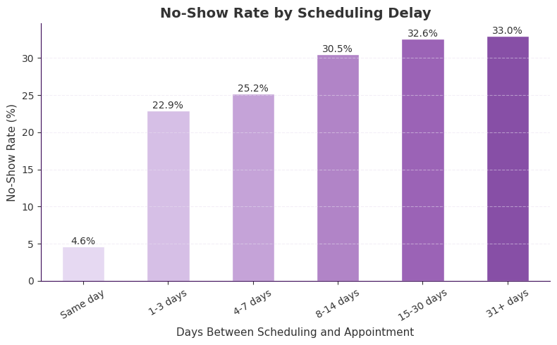

```python
# EDA 1: No-show rate by scheduling delay group
delay_rate = clean_df.groupby('delay_group', observed=False)['no_show_flag'].mean() * 100

ax = delay_rate.plot(
    kind='bar',
    figsize=(8, 5),
    color=purple_palette,
    edgecolor="white"
)

plt.title('No-Show Rate by Scheduling Delay')
plt.xlabel('Days Between Scheduling and Appointment')
plt.ylabel('No-Show Rate (%)')
plt.xticks(rotation=30)
plt.grid(axis='y', linestyle='--', alpha=0.5)

for i, v in enumerate(delay_rate):
    if pd.notna(v):
        ax.text(i, v + 0.3, f'{v:.1f}%', ha='center')

ax.spines[['top', 'right']].set_visible(False)

plt.tight_layout()
plt.show()
```

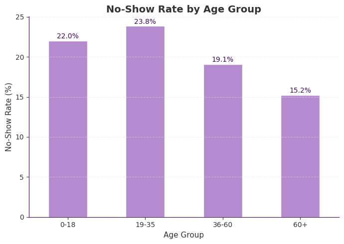

```python
# EDA 2: No-show rate by age group
age_rate = clean_df.groupby('age_group', observed=False)['no_show_flag'].mean() * 100

ax = age_rate.plot(
    kind='bar',
    figsize=(7, 5),
    color=bar_purple,          # uses your theme color
    edgecolor="white"
)

plt.title('No-Show Rate by Age Group')
plt.xlabel('Age Group')
plt.ylabel('No-Show Rate (%)')
plt.xticks(rotation=0)

plt.grid(axis='y', linestyle='--', alpha=0.5)

# Value labels (match darker purple tone)
for i, v in enumerate(age_rate):
    if pd.notna(v):
        ax.text(i, v + 0.3, f'{v:.1f}%', ha='center', color=dark_purple)

# Aesthetics
ax.spines[['top', 'right']].set_visible(False)

plt.tight_layout()
plt.show()
```

The scheduling delay graph should be a central figure in the final tutorial because it directly supports the model. If longer lead times have higher no-show percentages, then `lead_time_days` is not just a descriptive feature; it is a theoretically meaningful predictor. This also responds to peer feedback suggesting that scheduling delay may interact with age or other patient factors.

This pattern suggests that time itself introduces uncertainty into patient behavior, reinforcing the importance of incorporating temporal features into predictive models.

From an operational perspective, clinics could use this insight to prioritize follow-up reminders or rescheduling outreach for patients with longer lead times.

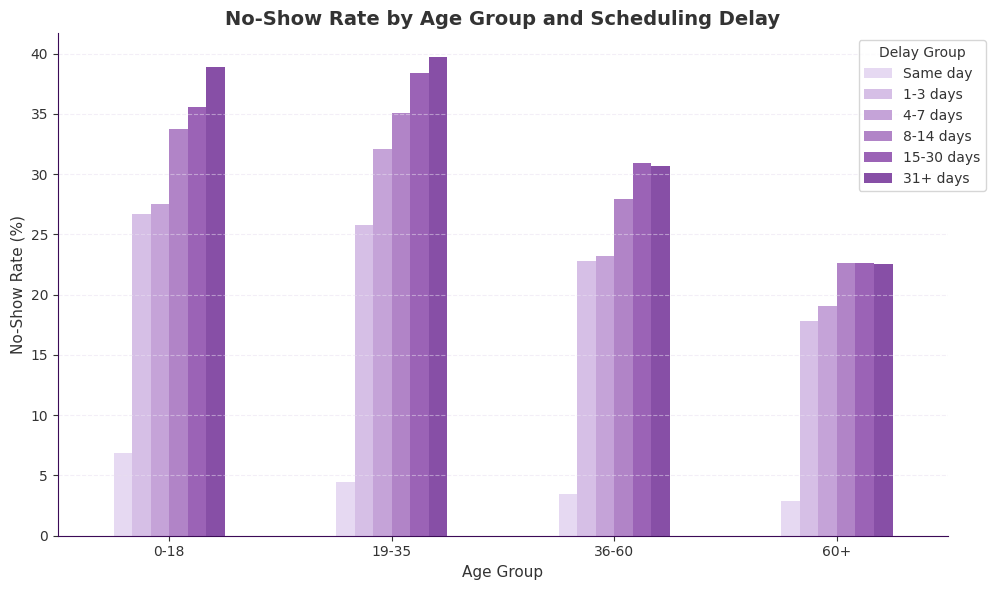

```python
# EDA 3: Scheduling delay and age together (grouped bar chart)
age_delay_table = (
    clean_df
    .groupby(['age_group', 'delay_group'], observed=False)['no_show_flag']
    .mean()
    .mul(100)
    .unstack()
)

ax = age_delay_table.plot(
    kind='bar',
    figsize=(10, 6),
    color=purple_palette
)

plt.title('No-Show Rate by Age Group and Scheduling Delay')
plt.xlabel('Age Group')
plt.ylabel('No-Show Rate (%)')
plt.xticks(rotation=0)
plt.legend(title='Delay Group', bbox_to_anchor=(1.05, 1))

plt.grid(axis='y', linestyle='--', alpha=0.5)
ax.spines[['top', 'right']].set_visible(False)

plt.tight_layout()
plt.show()
```

```python
age_delay_table.head()
```

| delay_group age_group | Same day | 1-3 days | 4-7 days | 8-14 days | 15-30 days | 31+ days |
| --- | --- | --- | --- | --- | --- | --- |
| 0-18 | 6.838546 | 26.683292 | 27.544277 | 33.735312 | 35.609543 | 38.909917 |
| 19-35 | 4.480797 | 25.793506 | 32.056398 | 35.116044 | 38.376027 | 39.703065 |
| 36-60 | 3.497577 | 22.826482 | 23.196517 | 27.938969 | 30.939321 | 30.679934 |
| 60+ | 2.907370 | 17.856159 | 19.061086 | 22.637363 | 22.650177 | 22.561576 |

This visualization shows how scheduling delay interacts with age to influence no-show rates. Across most age groups, longer delays are associated with higher no-show percentages, reinforcing the importance of lead time as a key predictor. This also suggests that different patient groups may benefit from tailored scheduling or reminder strategies rather than a uniform approach.

This indicates that demographic characteristics such as age may influence appointment adherence and should be included alongside operational variables in modeling.

This interaction suggests that targeted interventions could be designed for specific patient groups, rather than applying a one-size-fits-all scheduling strategy.

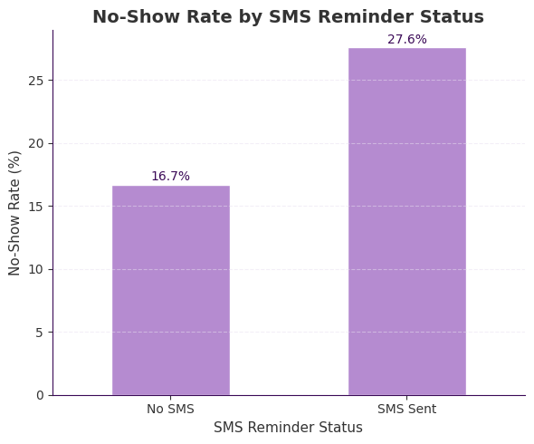

```python
# EDA 4: No-show rate by SMS reminder status
sms_rate = clean_df.groupby('sms_received')['no_show_flag'].mean() * 100
sms_rate.index = ['No SMS', 'SMS Sent']

ax = sms_rate.plot(
    kind='bar',
    figsize=(6, 5),
    color=bar_purple,
    edgecolor="white"
)

plt.title('No-Show Rate by SMS Reminder Status')
plt.xlabel('SMS Reminder Status')
plt.ylabel('No-Show Rate (%)')
plt.xticks(rotation=0)

plt.grid(axis='y', linestyle='--', alpha=0.5)

# Value labels
for i, v in enumerate(sms_rate):
    ax.text(i, v + 0.3, f'{v:.1f}%', ha='center', color=dark_purple)

# Aesthetics
ax.spines[['top', 'right']].set_visible(False)

plt.tight_layout()
plt.show()
```

The SMS result must be interpreted carefully. If the SMS group has a higher no-show rate, that does not prove that reminders cause no-shows. It may mean that SMS reminders were sent to patients already at higher risk or to appointments scheduled farther in advance. This is a classic example of why correlation is not causation and why a predictive model must control for multiple features at the same time.

This reinforces the need for multivariable modeling, since single-variable interpretations can be misleading without controlling for confounding factors.

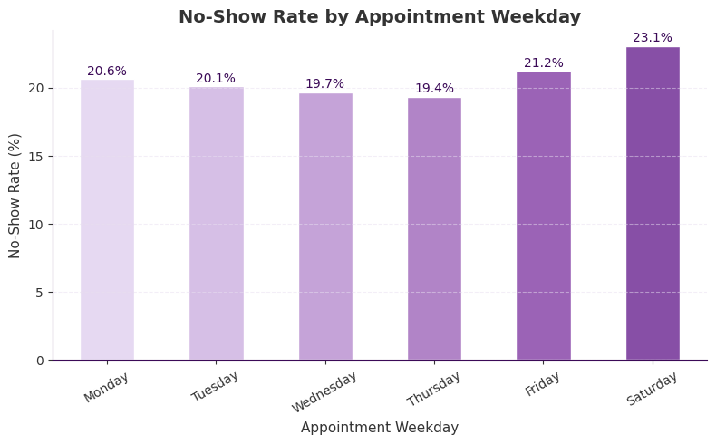

```python
# EDA 5: No-show rate by appointment weekday
weekday_order = ['Monday', 'Tuesday', 'Wednesday', 'Thursday', 'Friday', 'Saturday', 'Sunday']
weekday_rate = clean_df.groupby('appointment_weekday')['no_show_flag'].mean().reindex(weekday_order) * 100
weekday_rate = weekday_rate.dropna()

ax = weekday_rate.plot(
    kind='bar',
    figsize=(8, 5),
    color=purple_palette[:len(weekday_rate)],  # gradient effect
    edgecolor="white"
)

plt.title('No-Show Rate by Appointment Weekday')
plt.xlabel('Appointment Weekday')
plt.ylabel('No-Show Rate (%)')
plt.xticks(rotation=30)

plt.grid(axis='y', linestyle='--', alpha=0.5)

# Value labels
for i, v in enumerate(weekday_rate):
    ax.text(i, v + 0.3, f'{v:.1f}%', ha='center', color=dark_purple)

# Aesthetics
ax.spines[['top', 'right']].set_visible(False)

plt.tight_layout()
plt.show()
```

This suggests that structural scheduling factors, such as day-of-week patterns, may influence attendance and can contribute incremental predictive value.

## 6. Model Selection: Why Logistic Regression?

The final model uses **logistic regression** because the response variable is binary: an appointment is either missed or attended. Logistic regression is a strong first model for this project because it is interpretable, appropriate for classification, and commonly used in healthcare and social science settings where explanation matters.

A more complex model such as random forest could potentially improve predictive performance, but the goal of this tutorial is not only prediction. The goal is also to explain which variables are associated with no-show risk. Logistic regression makes it easier to connect model results back to the EDA and to discuss coefficients, odds, and operational recommendations.

The model uses a train/test split so that evaluation is performed on data the model did not see during training. This directly addresses the instructor feedback that the final notebook needs implementation and prediction results, not only a model proposal.

While performance is moderate, the model prioritizes interpretability, which is critical in healthcare decision-making contexts.

```python
# Select model features
# These are chosen because EDA and domain reasoning suggest they may relate to no-show behavior.
features = [
    'age',
    'lead_time_days',
    'sms_received',
    'appointment_weekday',
    'scholarship',
    'hipertension',
    'diabetes',
    'alcoholism',
    'handcap'
]

target = 'no_show_flag'

# Drop rows with missing values in the selected columns
model_df = clean_df[features + [target]].dropna().copy()

X = model_df[features]
y = model_df[target]

print(f"Modeling rows: {len(model_df):,}")
print(f"No-show rate in modeling data: {y.mean() * 100:.2f}%")
```

```
Modeling rows: 110,521
No-show rate in modeling data: 20.19%
```

```python
# Identify numeric and categorical features
numeric_features = ['age', 'lead_time_days']
categorical_features = [
    'sms_received',
    'appointment_weekday',
    'scholarship',
    'hipertension',
    'diabetes',
    'alcoholism',
    'handcap'
]

# Preprocessing: scale numeric variables and one-hot encode categorical variables
preprocessor = ColumnTransformer(
    transformers=[
        ('num', StandardScaler(), numeric_features),
        ('cat', OneHotEncoder(drop='first', handle_unknown='ignore'), categorical_features)
    ]
)

# Logistic regression pipeline
log_reg_model = Pipeline(
    steps=[
        ('preprocess', preprocessor),
        ('classifier', LogisticRegression(max_iter=1000, class_weight='balanced'))
    ]
)
```

```python
# Train/test split
# Stratify preserves the same approximate no-show rate in both train and test sets.
X_train, X_test, y_train, y_test = train_test_split(
    X,
    y,
    test_size=0.25,
    random_state=42,
    stratify=y
)

print(f"Training rows: {len(X_train):,}")
print(f"Testing rows: {len(X_test):,}")
print(f"Training no-show rate: {y_train.mean() * 100:.2f}%")
print(f"Testing no-show rate: {y_test.mean() * 100:.2f}%")
```

```
Training rows: 82,890
Testing rows: 27,631
Training no-show rate: 20.19%
Testing no-show rate: 20.19%
```

```python
# Fit the model
log_reg_model.fit(X_train, y_train)

# Predictions
predicted_labels = log_reg_model.predict(X_test)
predicted_probabilities = log_reg_model.predict_proba(X_test)[:, 1]
```

```python
# Model evaluation metrics
metrics = {
    'Accuracy': accuracy_score(y_test, predicted_labels),
    'Precision': precision_score(y_test, predicted_labels),
    'Recall': recall_score(y_test, predicted_labels),
    'F1 Score': f1_score(y_test, predicted_labels),
    'ROC-AUC': roc_auc_score(y_test, predicted_probabilities)
}

metrics_df = pd.DataFrame(metrics, index=['Logistic Regression']).T
metrics_df
```

|  | Logistic Regression |
| --- | --- |
| Accuracy | 0.664399 |
| Precision | 0.314484 |
| Recall | 0.561212 |
| F1 Score | 0.403090 |
| ROC-AUC | 0.666188 |

### Interpreting the Metrics

Accuracy alone can be misleading because most patients attend their appointments. A model that predicts every patient will attend could achieve a superficially high accuracy while failing to identify missed appointments. For this reason, precision, recall, F1 score, and ROC-AUC are included.

For this project, **recall** is especially important because it measures how many true no-shows the model successfully identifies. In a clinic workflow, missing a high-risk appointment may mean losing the chance to send an extra reminder or offer additional support. Precision is also important because too many false positives could waste staff time. The best operational model would balance recall with practical outreach capacity.

```python
# Classification report
print(classification_report(y_test, predicted_labels, target_names=['Attended', 'No-show']))
```

```
              precision    recall  f1-score   support

    Attended       0.86      0.69      0.77     22052
     No-show       0.31      0.56      0.40      5579

    accuracy                           0.66     27631
   macro avg       0.59      0.63      0.58     27631
weighted avg       0.75      0.66      0.69     27631
```

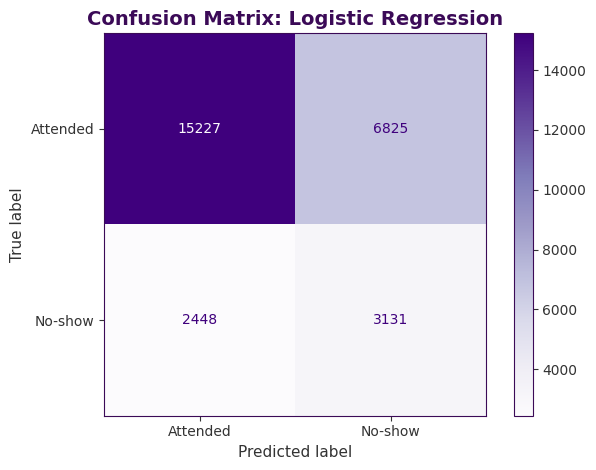

```python
# Confusion matrix
cm = confusion_matrix(y_test, predicted_labels)

disp = ConfusionMatrixDisplay(
    confusion_matrix=cm,
    display_labels=['Attended', 'No-show']
)

disp.plot(
    cmap="Purples",
    values_format='d'
)

plt.title('Confusion Matrix: Logistic Regression', color=dark_purple)

# Aesthetics for consistency
plt.grid(False)

plt.tight_layout()
plt.show()
```

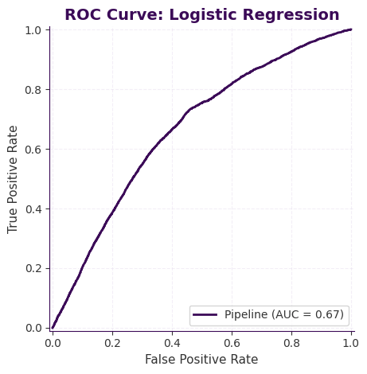

```python
# ROC curve
RocCurveDisplay.from_estimator(
    log_reg_model,
    X_test,
    y_test,
    color=dark_purple,
    linewidth=2
)

plt.title('ROC Curve: Logistic Regression', color=dark_purple)
plt.xlabel('False Positive Rate')
plt.ylabel('True Positive Rate')

# Lavender grid
plt.grid(True, linestyle='--', alpha=0.5)

# Clean aesthetic
ax = plt.gca()
ax.spines[['top', 'right']].set_visible(False)

plt.tight_layout()
plt.show()
```

## 7. Feature Interpretation

Because logistic regression is interpretable, the coefficients can help explain how features contribute to predicted no-show risk. Positive coefficients increase the predicted log-odds of a no-show, while negative coefficients decrease the predicted log-odds. Since numeric features were standardized, coefficient magnitudes are more comparable for age and lead time.

```python
# Extract feature names after preprocessing
feature_names = log_reg_model.named_steps['preprocess'].get_feature_names_out()
coefficients = log_reg_model.named_steps['classifier'].coef_[0]

coef_df = pd.DataFrame({
    'feature': feature_names,
    'coefficient': coefficients,
    'odds_ratio': np.exp(coefficients)
}).sort_values('coefficient', ascending=False)

coef_df.head(15)
```

|  | feature | coefficient | odds_ratio |
| --- | --- | --- | --- |
| 1 | num__lead_time_days | 0.420623 | 1.522909 |
| 2 | cat__sms_received_1 | 0.389127 | 1.475692 |
| 8 | cat__scholarship_1 | 0.235316 | 1.265308 |
| 11 | cat__alcoholism_1 | 0.189798 | 1.209005 |
| 10 | cat__diabetes_1 | 0.100565 | 1.105796 |
| 12 | cat__handcap_1 | 0.036749 | 1.037433 |
| 4 | cat__appointment_weekday_Saturday | 0.014667 | 1.014775 |
| 13 | cat__handcap_2 | 0.012104 | 1.012177 |
| 14 | cat__handcap_3 | 0.003744 | 1.003751 |
| 9 | cat__hipertension_1 | 0.000042 | 1.000042 |
| 15 | cat__handcap_4 | -0.002029 | 0.997973 |
| 3 | cat__appointment_weekday_Monday | -0.137527 | 0.871511 |
| 5 | cat__appointment_weekday_Thursday | -0.145644 | 0.864465 |
| 7 | cat__appointment_weekday_Wednesday | -0.162220 | 0.850254 |
| 0 | num__age | -0.172519 | 0.841542 |

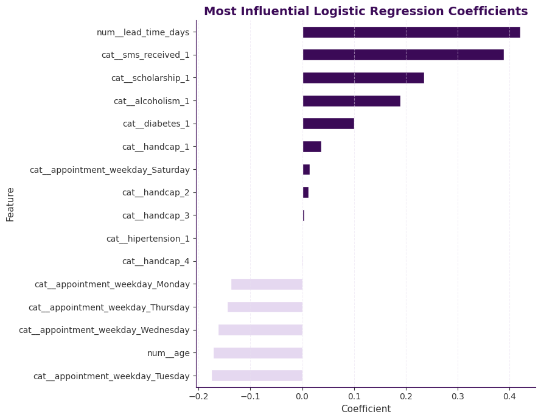

```python
# Visualize the most influential positive and negative coefficients
coef_plot_df = pd.concat([
    coef_df.head(8),
    coef_df.tail(8)
]).sort_values('coefficient')

# Color bars based on sign
colors = [
    dark_purple if val > 0 else light_purple
    for val in coef_plot_df['coefficient']
]

ax = coef_plot_df.plot(
    x='feature',
    y='coefficient',
    kind='barh',
    figsize=(9, 7),
    color=colors,
    edgecolor="white",
    legend=False
)

plt.title('Most Influential Logistic Regression Coefficients', color=dark_purple)
plt.xlabel('Coefficient')
plt.ylabel('Feature')

# Aesthetics
plt.grid(axis='x', linestyle='--', alpha=0.5)

ax.spines[['top', 'right']].set_visible(False)

plt.tight_layout()
plt.show()
```

## 8. Conclusions and Recommendations

This project shows that medical appointment no-shows can be studied as both an operational healthcare issue and a predictive data science problem. The exploratory analysis suggests that scheduling delay, age, SMS reminder status, weekday, and health/social indicators are associated with appointment attendance. The logistic regression model then tests whether these variables can be used together to predict no-show risk on unseen test data.

The most important conclusion is that scheduling delay should be treated as a major operational signal. Appointments scheduled far in advance may require additional support because patients have more time to forget, experience schedule conflicts, lose transportation, or become disconnected from the original reason for the visit. This does not mean long-delay patients are irresponsible; it suggests that clinic systems may need stronger follow-up workflows for appointments booked weeks in advance.

A second conclusion is that SMS reminders should be interpreted carefully. If the EDA shows that SMS recipients have higher no-show rates, this should not be described as proof that SMS reminders are ineffective. A more reasonable explanation is that SMS reminders may be associated with patients or appointments that already have higher risk. This is why the model includes SMS along with other variables rather than interpreting the SMS graph in isolation.

The model should be used as a decision-support tool, not as a final authority. A clinic could use predicted risk scores to prioritize extra reminder calls, transportation-resource information, earlier waitlist offers, or flexible rescheduling messages. The ethical goal should be improving access and reducing missed care, not penalizing patients.

### Limitations

This analysis is observational, so it identifies associations rather than causal effects. The dataset comes from a Brazilian healthcare setting, so results may not generalize directly to every outpatient clinic or specialty. The supplemental socioeconomic dataset from Milestone 2 was manually constructed and too small to support strong claims unless it is expanded and made downloadable. Future work could improve the model by adding distance to clinic, appointment type, provider specialty, insurance/access variables, reminder timing, and prior attendance history.

From an operational standpoint, clinics could implement several practical strategies based on these findings. For example, patients with longer scheduling delays could be flagged for additional reminders or follow-up contact closer to the appointment date. Clinics could also experiment with scheduling policies that reduce long lead times when possible, or offer waitlist opportunities to re-engage patients. More advanced systems could integrate predictive risk scores directly into scheduling dashboards, allowing staff to proactively manage high-risk appointments. These interventions align with findings in healthcare research, where predictive models have been shown to improve attendance rates and overall clinic efficiency when used as decision-support tools ([Healthcare Study on Predictive No-Show Modeling](https://pmc.ncbi.nlm.nih.gov/articles/PMC11545362/)).

Overall, this project demonstrates how even simple, interpretable models can support more efficient, patient-centered healthcare systems.

### References

#### Healthcare Research & Real-World Applications

- [Healthcare Study on Predictive No-Show Modeling](https://pmc.ncbi.nlm.nih.gov/articles/PMC11545362/)  
  This study supports the use of predictive models as decision-support tools in healthcare settings, demonstrating improvements in patient attendance and operational efficiency.
- [How Machine Learning Can Predict Patient No-Shows (AAPC)](https://www.aapc.com/blog/93112-can-machine-learning-predict-patient-no-shows/)  
  This article highlights how predictive analytics can be used in practice to identify high-risk patients and guide targeted interventions such as reminders and scheduling adjustments.